# Homework 2

DACSS-603

Katie Popiela  
3/24/2022

## Question 1

(Problem 1.1 in ALR) United Nations (Data file: UN11) The data in the file UN11 contains several variables, including ppgdp, the gross national product per person in U.S. dollars, and fertility, the birth rate per 1000 females, both from the year 2009. The data are for 199 localities, mostly UN member countries, but also other areas such as Hong Kong that are not independent countries. The data were collected from the United Nations (2011). We will study the dependence of fertility on ppgdp.

### a. Identify the predictor and the response

Predictor: ppgdp  
Response: fertility

### b. Draw the scatterplot of “fertility” on the vertical axis versus “ppgdp” on the horizontal axis and summarize the information in the graph. Does a straight-line mean function seem to be plausible for a summary of this graph?

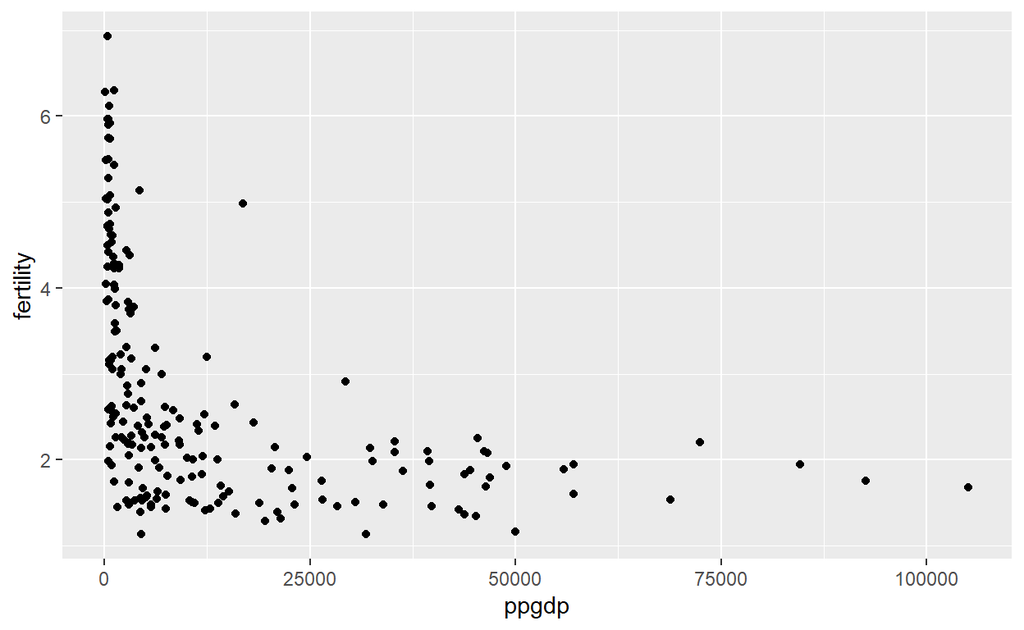

```r
library(alr4)
data(UN11)

library(ggplot2)
ggplot(data = UN11, aes(x=ppgdp,y=fertility)) + geom_point()
```

The scatterplot shows a marked decline in fertility rates as GDP increases. I will now recreate the scatterplot with a straight-line function to see if it appears to be appropriate for this presentation of the data.

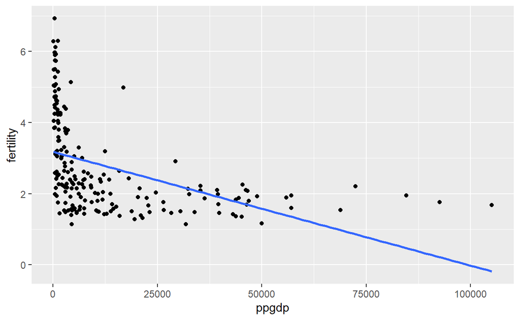

```r
data(UN11)
ggplot(data = UN11, aes(x=ppgdp,y=fertility)) + geom_point()+
  geom_smooth(method="lm",se=FALSE)
```

As can be seen above, a straight-line function is not appropriate; the data is not currently presented in a linear manner (the data is L-shaped). I will now try a linear regression model to see if a straight-line funtion is applicable there.

### c. Draw the scatterplot of log(fertility) versus log(ppgdp) using natural logarithms. Does the simple linear regression model seem plausible for a summary of this graph? If you use a different base of logarithms, the shape of the graph won’t change, but the values on the axes will change.

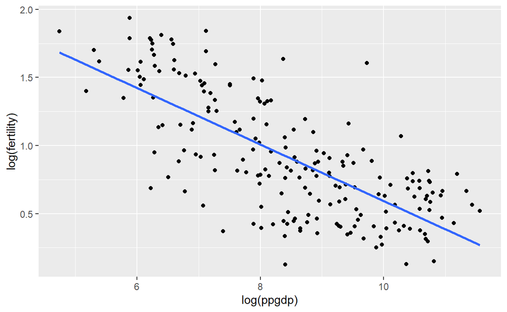

```r
data(UN11)
ggplot(data = UN11, aes(x=log(ppgdp),y=log(fertility))) + geom_point() +
  geom_smooth(method="lm",se=FALSE)
```

A simple linear regression model is much more plausible for a straight-line function.

## Question 2

(Problem 9.47 in SMSS) Annual income, in dollars, is an explanatory variable in a regression analysis. For a British version of the report on the analysis, all responses are converted to British pounds sterling (1 pound equals about 1.33 dollars, as of 2016).

### a. How, if at all, does the slope prediction equation change?

To account for the conversion rate from USD to GBP, the value of the response must be divided by 1.33. The slope shall also be divided by 1.33.

### b. How, if at all, does the correlation change?

Correlation isn’t affected by units of measurement, so it would not change in this scenario.

## Question 3

(Problem 1.5 in ALR) Water runoff in the Sierras (Data file: water) Can Southern California’s water supply in future years be predicted from past data? One factor affecting water availability is stream runoff. If runoff could be predicted, engineers, planners, and policy makers could do their jobs more efficiently. The data file contains 43 years’ worth of precipitation measurements taken at six sites in the Sierra Nevada mountains (labeled APMAM, APSAB, APSLAKE, OPBPC, OPRC, and OPSLAKE) and stream runoff volume at a site near Bishop, California, labeled BSAAM. Draw the scatterplot matrix for these data and summarize the information available from these plots.

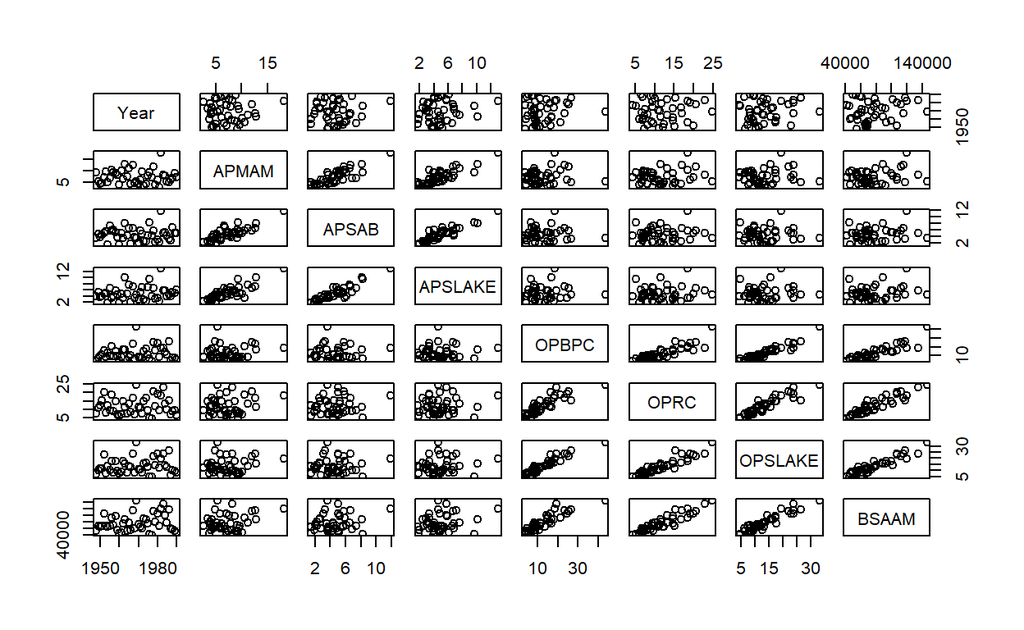

```r
library(alr4)
data(water)
pairs(water)
```

Since this matrix presents a lot of information, I’ll summarize:  
* Year doesn’t seem to be related to runoff or water levels  
* The following variables appear to be correlated with each other: OPBPC, OPRC, OPSLAKE. All parts of the matrix with 2 of these variables exhibit a dependence among themselves that is not present between OPBPC, OPRC, and OPSLAKE and APMAM, APSAB, APSLAKE. That being said, though, there also appears to be a correlation among APMAM, APSAB, APSLAKE.  
* BSAAM is more closely related to OPBPC, OPRC, and OPSLAKE than to APMAM, APSAB, APSLAKE.

## Question 4

(Problem 1.6 in ALR, modified) Professor ratings (Data file: Rateprof) In the website and online forum RateMyProfessors.com, students rate and comment on their instructors. Launched in 1999, the site includes millions of ratings on thousands of instructors. The data file includes the summaries of the ratings of 364 instructors at a large campus in the Midwest (Bleske-Rechek and Fritsch, 2011). Each instructor included in the data had at least 10 ratings over a several year period. Students provided ratings of 1–5 on quality, helpfulness, clarity, easiness of instructor’s courses, and raterInterest in the subject matter covered in the instructor’s courses. The data file provides the averages of these five ratings. Use R to reproduce the scatterplot matrix in Figure 1.13 in the ALR book (page 20). Provide a brief description of the relationships between the five ratings. (The variables don’t have to be in the same order)

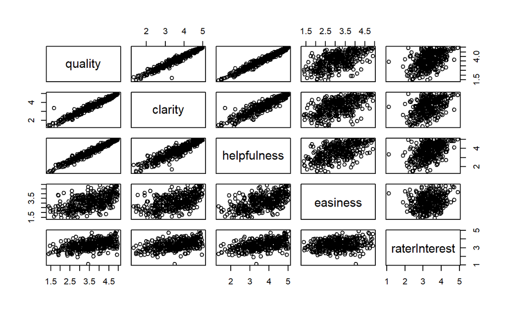

```r
library(alr4)
data(Rateprof)
pairs(Rateprof[c("quality","clarity","helpfulness","easiness","raterInterest")])
```

There is a strong correlation among “quality”, “clarity”, and “helpfulness.” As those variables increase, so too do the professors’ ratings. This makes sense as the quality and clarity of the material, as well as the professor’s helpfulness are major factors in undergraduate learning. There appears to be some correlation among “helpfulness” and “easiness” but the data is much more dispersed. “raterInterest” seems pretty consistent in the middle of each graph, indicating that the rater is at least moderately interested in the subject matter of the courses they are rating.

## Question 5

(Problem 9.34 in SMSS) For the “student.survey” data file in the smss package, conduce regression analyses relating:  
a. y = political ideology and x = religiosity  
b. y = high school GPA and x = hours of TV watching  
(You can use ?student.survey in the R console after loading the package to see what each variable means)  
* Use graphical ways to portray the individual variables and their relationships.  
* Interpret descriptive statistics for summarizing the individual variables and their relationships.  
* Summarize and interpret the results of inferential analyses.

```r
library(ggplot2)

library(smss)
data("student.survey")
colnames(student.survey)
```

```
 [1] "subj" "ge"   "ag"   "hi"   "co"   "dh"   "dr"   "tv"   "sp"
[10] "ne"   "ah"   "ve"   "pa"   "pi"   "re"   "ab"   "aa"   "ld"
```

The variables I will be focusing on (as per the problem) are “re” (x) and “pi” (y) for subsection (a); and then “hi” (x) and “tv” (y) for subsection (b)

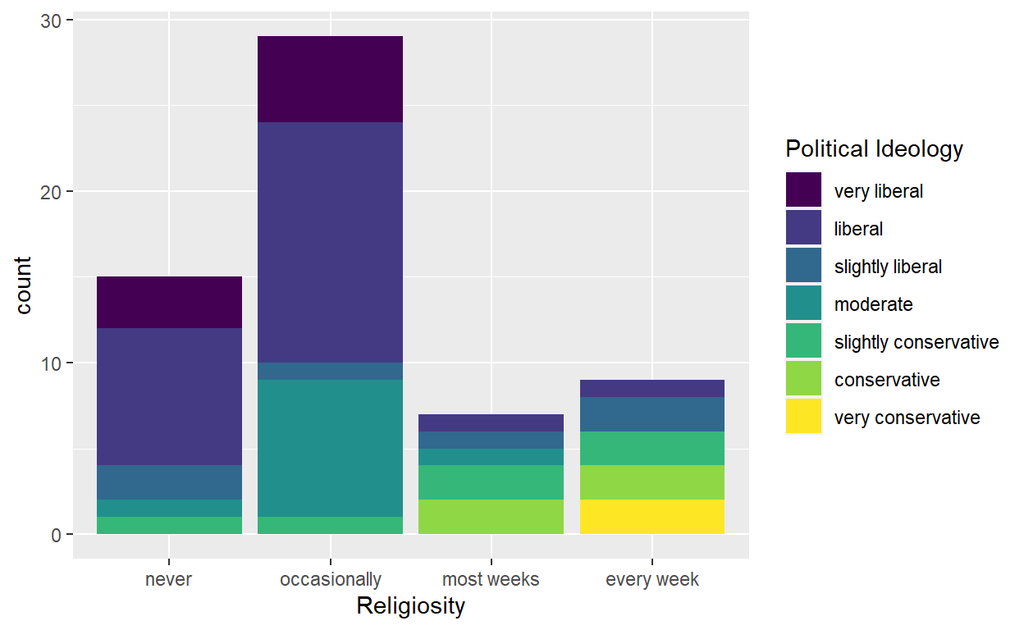

```r
library(smss)
data("student.survey")
ggplot(data=student.survey,aes(x=re,fill=pi))+
  geom_bar() + labs(x="Religiosity", fill ="Political Ideology")
```

The graph above is one (of several possible) visualizations of the relationship between religiosity and political ideology. I couldn’t figure out how to get more info on what exactly the variables mean, so I’m assuming “Religiosity” refers to the frequency individuals of different political ideologies go to church/temple/mosque/etc.. From left to right, the frequency goes from “never” to “every week.” As frequency increases, so too does conservatism. While not a majority by any means, it is still significant to note that those who identify as very conservative only appear in the bar labelled “every week,” whereas those who identify as very liberal are not even present on the graph to the right of “occasionally.” This, therefore, indicates that those who are heavily liberal-leaning in political ideology are far less likely to go to church/temple/mosque/etc. regularly/frequently than those who are more conservative.

### b. y = high school GPA and x = hours of TV watching

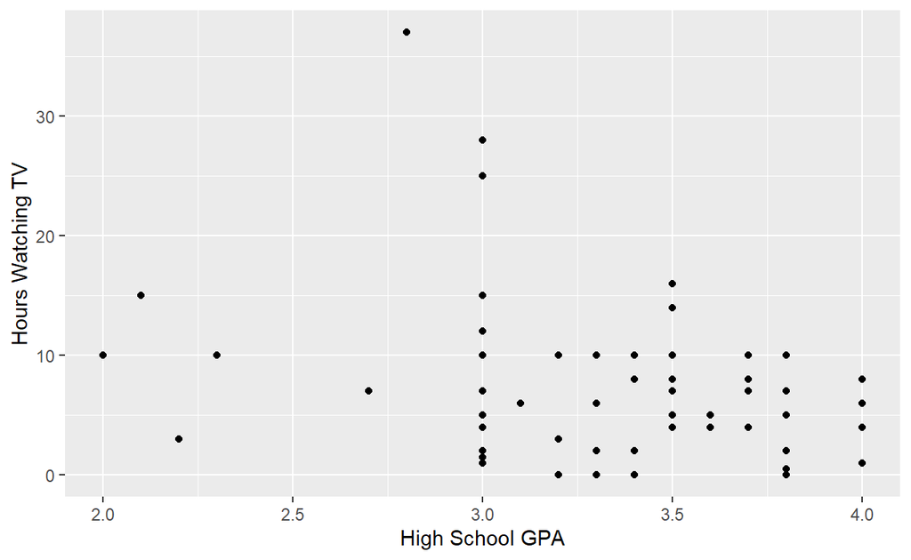

```r
data("student.survey")
ggplot(data=student.survey,aes(x=hi, y=tv)) +
  geom_point() + labs(x="High School GPA", y="Hours Watching TV")
```

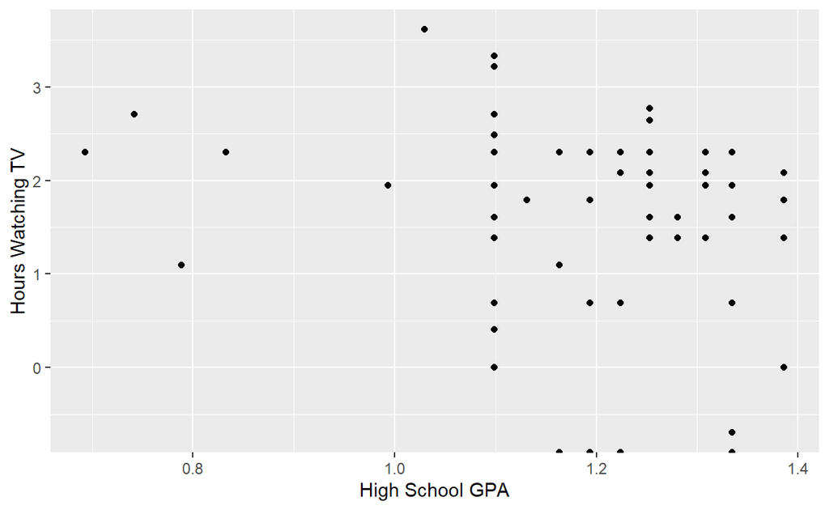

```r
ggplot(data = student.survey, aes(x=log(hi),y=log(tv))) + geom_point() +
  labs(x="High School GPA",y="Hours Watching TV")
```

Now I will present some descriptive/summary statistics of all 4 variables to show their statistical significance.

```r
summary(student.survey[,c('pi', 're', 'hi', 'tv')])
```

```
                     pi                re           hi
 very liberal         : 8   never       :15   Min.   :2.000
 liberal              :24   occasionally:29   1st Qu.:3.000
 slightly liberal     : 6   most weeks  : 7   Median :3.350
 moderate             :10   every week  : 9   Mean   :3.308
 slightly conservative: 6                     3rd Qu.:3.625
 conservative         : 4                     Max.   :4.000
 very conservative    : 2
       tv
 Min.   : 0.000
 1st Qu.: 3.000
 Median : 6.000
 Mean   : 7.267
 3rd Qu.:10.000
 Max.   :37.000
```

Since each sample has a different number of subjects/respondents, the results are somewhat skewed.The distribution of high school GPA looks relatively normal and unimodal. The distribution of “Hours Watching TV” on the other hand, has several outliers which can be seen both on the above graph and in the summary statistics via the difference between the 3rd quartile and maximum values.